# Bellabeat Case Study

Shannon Sanders

2022-04-14

#### **Background:**

Bellabeat is a high-tech company that manufactures health-focused smart products. Collecting data on activity, sleep, stress, and reproductive health has allowed Bellabeat to empower women with knowledge about their own health and habits. Since it was founded in 2013, Bellabeat has grown rapidly and quickly positioned itself as a tech-driven wellness company for women.

#### **Business Objective:**

Analyze FitBit smart device usage data in order to gain insight into how consumers use non-Bellabeat smart devices. Apply that knowledge to one Bellabeat product to influence marketing strategy.

#### **Data & Tools Used:**

This dataset was derived from FitBit Fitness Tracker Data, which is a public dataset on Kaggle. The data consists of minute-level output for daily physical activity, heart rate, and sleep monitoring. It includes many tables in both long and wide format of different aspects of device usage and user behavior.

R was chosen for this case study because it can clean, transform, analyze, and visualize data all in one place. The dataset is also relatively small, making it is a better choice than SQL/Tableau.

## **Preparing Data**

#### **Load the packages**

```r
library(readr)
library(tidyverse)
library(janitor)
library(lubridate)
```

```r
library(dplyr)
library(ggplot2)
```

#### **Import the datasets**

```r
daily <- read_csv("dailyActivity.csv")
calories <- read_csv("dailyCalories.csv")
intensities <- read_csv("dailyIntensities.csv")
steps <- read_csv("dailySteps.csv")
hr <- read_csv("heartrateSeconds.csv")
sleep <- read_csv("sleepDay.csv")
weight <- read_csv("weightLogInfo.csv")
hourlyInt <- read_csv("hourlyIntensities.csv")
```

#### **Read the data**

```r
head(daily)
```

```
## # A tibble: 6 × 15
##        Id ActivityDate TotalSteps TotalDistance TrackerDistance LoggedActivitie…
##     <dbl> <chr>             <dbl>         <dbl>           <dbl>            <dbl>
## 1  1.50e9 4/12/2016         13162          8.5             8.5                 0
## 2  1.50e9 4/13/2016         10735          6.97            6.97                0
## 3  1.50e9 4/14/2016         10460          6.74            6.74                0
## 4  1.50e9 4/15/2016          9762          6.28            6.28                0
## 5  1.50e9 4/16/2016         12669          8.16            8.16                0
## 6  1.50e9 4/17/2016          9705          6.48            6.48                0
## # … with 9 more variables: VeryActiveDistance <dbl>,
## #   ModeratelyActiveDistance <dbl>, LightActiveDistance <dbl>,
## #   SedentaryActiveDistance <dbl>, VeryActiveMinutes <dbl>,
## #   FairlyActiveMinutes <dbl>, LightlyActiveMinutes <dbl>,
## #   SedentaryMinutes <dbl>, Calories <dbl>
```

```r
head(calories)
```

```
## # A tibble: 6 × 3
##           Id ActivityDay Calories
##        <dbl> <chr>          <dbl>
## 1 1503960366 4/12/2016       1985
## 2 1503960366 4/13/2016       1797
## 3 1503960366 4/14/2016       1776
## 4 1503960366 4/15/2016       1745
## 5 1503960366 4/16/2016       1863
## 6 1503960366 4/17/2016       1728
```

```r
head(intensities)
```

```
## # A tibble: 6 × 10
##           Id ActivityDay SedentaryMinutes LightlyActiveMinutes FairlyActiveMinu…
##        <dbl> <chr>                  <dbl>                <dbl>             <dbl>
## 1 1503960366 4/12/2016                728                  328                13
## 2 1503960366 4/13/2016                776                  217                19
## 3 1503960366 4/14/2016               1218                  181                11
## 4 1503960366 4/15/2016                726                  209                34
## 5 1503960366 4/16/2016                773                  221                10
## 6 1503960366 4/17/2016                539                  164                20
## # … with 5 more variables: VeryActiveMinutes <dbl>,
## #   SedentaryActiveDistance <dbl>, LightActiveDistance <dbl>,
## #   ModeratelyActiveDistance <dbl>, VeryActiveDistance <dbl>
```

```r
head(steps)
```

```
## # A tibble: 6 × 3
##           Id ActivityDay StepTotal
##        <dbl> <chr>           <dbl>
## 1 1503960366 4/12/2016       13162
## 2 1503960366 4/13/2016       10735
## 3 1503960366 4/14/2016       10460
## 4 1503960366 4/15/2016        9762
## 5 1503960366 4/16/2016       12669
## 6 1503960366 4/17/2016        9705
```

```r
head(hr)
```

```
## # A tibble: 6 × 3
##           Id Time                 Value
##        <dbl> <chr>                <dbl>
## 1 2022484408 4/12/2016 7:21:00 AM    97
## 2 2022484408 4/12/2016 7:21:05 AM   102
## 3 2022484408 4/12/2016 7:21:10 AM   105
## 4 2022484408 4/12/2016 7:21:20 AM   103
## 5 2022484408 4/12/2016 7:21:25 AM   101
## 6 2022484408 4/12/2016 7:22:05 AM    95
```

```r
head(sleep)
```

```
## # A tibble: 6 × 5
##           Id SleepDay           TotalSleepRecor… TotalMinutesAsl… TotalTimeInBed
##        <dbl> <chr>                         <dbl>            <dbl>          <dbl>
## 1 1503960366 4/12/2016 12:00:0…                1              327            346
## 2 1503960366 4/13/2016 12:00:0…                2              384            407
## 3 1503960366 4/15/2016 12:00:0…                1              412            442
## 4 1503960366 4/16/2016 12:00:0…                2              340            367
## 5 1503960366 4/17/2016 12:00:0…                1              700            712
## 6 1503960366 4/19/2016 12:00:0…                1              304            320
```

```r
head(weight)
```

```
## # A tibble: 6 × 8
##           Id Date       WeightKg WeightPounds   Fat   BMI IsManualReport   LogId
##        <dbl> <chr>         <dbl>        <dbl> <dbl> <dbl> <lgl>            <dbl>
## 1 1503960366 5/2/2016 …     52.6         116.    22  22.6 TRUE           1.46e12
## 2 1503960366 5/3/2016 …     52.6         116.    NA  22.6 TRUE           1.46e12
## 3 1927972279 4/13/2016…    134.          294.    NA  47.5 FALSE          1.46e12
## 4 2873212765 4/21/2016…     56.7         125.    NA  21.5 TRUE           1.46e12
## 5 2873212765 5/12/2016…     57.3         126.    NA  21.7 TRUE           1.46e12
## 6 4319703577 4/17/2016…     72.4         160.    25  27.5 TRUE           1.46e12
```

```r
head(hourlyInt)
```

```
## # A tibble: 6 × 4
##           Id ActivityHour          TotalIntensity AverageIntensity
##        <dbl> <chr>                          <dbl>            <dbl>
## 1 1503960366 4/12/2016 12:00:00 AM             20            0.333
## 2 1503960366 4/12/2016 1:00:00 AM               8            0.133
## 3 1503960366 4/12/2016 2:00:00 AM               7            0.117
## 4 1503960366 4/12/2016 3:00:00 AM               0            0
## 5 1503960366 4/12/2016 4:00:00 AM               0            0
## 6 1503960366 4/12/2016 5:00:00 AM               0            0
```

Upon inspecting the data, I notice that each one has a column named “Id” which will help if I decide to merge data. There also seems to be a lot of data missing from the weight table. This makes me curious to see how many users are using all of the features. Then I will make sure all of the dates are formatted correctly.

**Look for missing values**

```r
sum(is.na(daily))
```

```
## [1] 0
```

```r
sum(is.na(calories))
```

```
## [1] 0
```

```r
sum(is.na(intensities))
```

```
## [1] 0
```

```r
sum(is.na(steps))
```

```
## [1] 0
```

```r
sum(is.na(hr))
```

```
## [1] 0
```

```r
sum(is.na(sleep))
```

```
## [1] 0
```

```r
sum(is.na(weight))
```

```
## [1] 65
```

```r
sum(is.na(hourlyInt))
```

```
## [1] 0
```

If the value is 0 there are no missing values. The weight df has 65 missing values, the rest of them aren’t missing any at all.

#### **Counting participants**

```r
n_distinct(daily$Id)
```

```
## [1] 33
```

```r
n_distinct(calories$Id)
```

```
## [1] 33
```

```r
n_distinct(intensities$Id)
```

```
## [1] 33
```

```r
n_distinct(steps$Id)
```

```
## [1] 33
```

```r
n_distinct(hr$Id)
```

```
## [1] 14
```

```r
n_distinct(sleep$Id)
```

```
## [1] 24
```

```r
n_distinct(weight$Id)
```

```
## [1] 8
```

```r
n_distinct(hourlyInt$Id)
```

```
## [1] 33
```

There are 33 distinct users in the majority of the tables, 14 in heartrate, 24 in sleep, and 8 in weight. I will omit heartrate and weight because it doesn’t seem those features are used as much.

#### **Formatting dates**

```r
daily$ActivityDate=as.POSIXct(daily$ActivityDate, format="%m/%d/%Y", tz=Sys.timezone())
daily$date <- format(daily$ActivityDate, format = "%m/%d/%y")

sleep$SleepDay=as.POSIXct(sleep$SleepDay, format="%m/%d/%Y %I:%M:%S %p", tz=Sys.timezone())
sleep$date <- format(sleep$SleepDay, format = "%m/%d/%y")

dhourlyInt <- hourlyInt %>%
  extract(ActivityHour, c("Date", "Hour"), "([^ ]+) (.*)")
```

I changed the dates from strings to date formats. I also separated the day and hour on the hourly tables.

## **Exploratory Analysis**

#### Looking at summaries

```r
summary(daily)
```

```
##        Id             ActivityDate                   TotalSteps
##  Min.   :1.504e+09   Min.   :2016-04-12 00:00:00   Min.   :    0
##  1st Qu.:2.320e+09   1st Qu.:2016-04-19 00:00:00   1st Qu.: 3790
##  Median :4.445e+09   Median :2016-04-26 00:00:00   Median : 7406
##  Mean   :4.855e+09   Mean   :2016-04-26 06:53:37   Mean   : 7638
##  3rd Qu.:6.962e+09   3rd Qu.:2016-05-04 00:00:00   3rd Qu.:10727
##  Max.   :8.878e+09   Max.   :2016-05-12 00:00:00   Max.   :36019
##  TotalDistance    TrackerDistance  LoggedActivitiesDistance VeryActiveDistance
##  Min.   : 0.000   Min.   : 0.000   Min.   :0.0000           Min.   : 0.000
##  1st Qu.: 2.620   1st Qu.: 2.620   1st Qu.:0.0000           1st Qu.: 0.000
##  Median : 5.245   Median : 5.245   Median :0.0000           Median : 0.210
##  Mean   : 5.490   Mean   : 5.475   Mean   :0.1082           Mean   : 1.503
##  3rd Qu.: 7.713   3rd Qu.: 7.710   3rd Qu.:0.0000           3rd Qu.: 2.053
##  Max.   :28.030   Max.   :28.030   Max.   :4.9421           Max.   :21.920
##  ModeratelyActiveDistance LightActiveDistance SedentaryActiveDistance
##  Min.   :0.0000           Min.   : 0.000      Min.   :0.000000
##  1st Qu.:0.0000           1st Qu.: 1.945      1st Qu.:0.000000
##  Median :0.2400           Median : 3.365      Median :0.000000
##  Mean   :0.5675           Mean   : 3.341      Mean   :0.001606
##  3rd Qu.:0.8000           3rd Qu.: 4.782      3rd Qu.:0.000000
##  Max.   :6.4800           Max.   :10.710      Max.   :0.110000
##  VeryActiveMinutes FairlyActiveMinutes LightlyActiveMinutes SedentaryMinutes
##  Min.   :  0.00    Min.   :  0.00      Min.   :  0.0        Min.   :   0.0
##  1st Qu.:  0.00    1st Qu.:  0.00      1st Qu.:127.0        1st Qu.: 729.8
##  Median :  4.00    Median :  6.00      Median :199.0        Median :1057.5
##  Mean   : 21.16    Mean   : 13.56      Mean   :192.8        Mean   : 991.2
##  3rd Qu.: 32.00    3rd Qu.: 19.00      3rd Qu.:264.0        3rd Qu.:1229.5
##  Max.   :210.00    Max.   :143.00      Max.   :518.0        Max.   :1440.0
##     Calories        date
##  Min.   :   0   Length:940
##  1st Qu.:1828   Class :character
##  Median :2134   Mode  :character
##  Mean   :2304
##  3rd Qu.:2793
##  Max.   :4900
```

```r
summary(calories)
```

```
##        Id            ActivityDay           Calories
##  Min.   :1.504e+09   Length:940         Min.   :   0
##  1st Qu.:2.320e+09   Class :character   1st Qu.:1828
##  Median :4.445e+09   Mode  :character   Median :2134
##  Mean   :4.855e+09                      Mean   :2304
##  3rd Qu.:6.962e+09                      3rd Qu.:2793
##  Max.   :8.878e+09                      Max.   :4900
```

```r
summary(intensities)
```

```
##        Id            ActivityDay        SedentaryMinutes LightlyActiveMinutes
##  Min.   :1.504e+09   Length:940         Min.   :   0.0   Min.   :  0.0
##  1st Qu.:2.320e+09   Class :character   1st Qu.: 729.8   1st Qu.:127.0
##  Median :4.445e+09   Mode  :character   Median :1057.5   Median :199.0
##  Mean   :4.855e+09                      Mean   : 991.2   Mean   :192.8
##  3rd Qu.:6.962e+09                      3rd Qu.:1229.5   3rd Qu.:264.0
##  Max.   :8.878e+09                      Max.   :1440.0   Max.   :518.0
##  FairlyActiveMinutes VeryActiveMinutes SedentaryActiveDistance
##  Min.   :  0.00      Min.   :  0.00    Min.   :0.000000
##  1st Qu.:  0.00      1st Qu.:  0.00    1st Qu.:0.000000
##  Median :  6.00      Median :  4.00    Median :0.000000
##  Mean   : 13.56      Mean   : 21.16    Mean   :0.001606
##  3rd Qu.: 19.00      3rd Qu.: 32.00    3rd Qu.:0.000000
##  Max.   :143.00      Max.   :210.00    Max.   :0.110000
##  LightActiveDistance ModeratelyActiveDistance VeryActiveDistance
##  Min.   : 0.000      Min.   :0.0000           Min.   : 0.000
##  1st Qu.: 1.945      1st Qu.:0.0000           1st Qu.: 0.000
##  Median : 3.365      Median :0.2400           Median : 0.210
##  Mean   : 3.341      Mean   :0.5675           Mean   : 1.503
##  3rd Qu.: 4.782      3rd Qu.:0.8000           3rd Qu.: 2.053
##  Max.   :10.710      Max.   :6.4800           Max.   :21.920
```

```r
summary(steps)
```

```
##        Id            ActivityDay          StepTotal
##  Min.   :1.504e+09   Length:940         Min.   :    0
##  1st Qu.:2.320e+09   Class :character   1st Qu.: 3790
##  Median :4.445e+09   Mode  :character   Median : 7406
##  Mean   :4.855e+09                      Mean   : 7638
##  3rd Qu.:6.962e+09                      3rd Qu.:10727
##  Max.   :8.878e+09                      Max.   :36019
```

```r
summary(sleep)
```

```
##        Id               SleepDay                   TotalSleepRecords
##  Min.   :1.504e+09   Min.   :2016-04-12 00:00:00   Min.   :1.000
##  1st Qu.:3.977e+09   1st Qu.:2016-04-19 00:00:00   1st Qu.:1.000
##  Median :4.703e+09   Median :2016-04-27 00:00:00   Median :1.000
##  Mean   :5.001e+09   Mean   :2016-04-26 12:40:05   Mean   :1.119
##  3rd Qu.:6.962e+09   3rd Qu.:2016-05-04 00:00:00   3rd Qu.:1.000
##  Max.   :8.792e+09   Max.   :2016-05-12 00:00:00   Max.   :3.000
##  TotalMinutesAsleep TotalTimeInBed      date
##  Min.   : 58.0      Min.   : 61.0   Length:413
##  1st Qu.:361.0      1st Qu.:403.0   Class :character
##  Median :433.0      Median :463.0   Mode  :character
##  Mean   :419.5      Mean   :458.6
##  3rd Qu.:490.0      3rd Qu.:526.0
##  Max.   :796.0      Max.   :961.0
```

```r
summary(hourlyInt)
```

```
##        Id            ActivityHour       TotalIntensity   AverageIntensity
##  Min.   :1.504e+09   Length:22099       Min.   :  0.00   Min.   :0.0000
##  1st Qu.:2.320e+09   Class :character   1st Qu.:  0.00   1st Qu.:0.0000
##  Median :4.445e+09   Mode  :character   Median :  3.00   Median :0.0500
##  Mean   :4.848e+09                      Mean   : 12.04   Mean   :0.2006
##  3rd Qu.:6.962e+09                      3rd Qu.: 16.00   3rd Qu.:0.2667
##  Max.   :8.878e+09                      Max.   :180.00   Max.   :3.0000
```

I can see a lot of information from the summaries.

#### Calculating unused device days

Lets first see how many days the 33 participants did not use their device. To do this, I will count the days where SedentaryMinutes = 1440, since 1440 is the total number of minutes in a day. It is highly unlikely that participants did not move at all for a whole day. It makes more sense that the fitbit was not used during those days.

```r
deviceUnused <- daily %>%
  filter(SedentaryMinutes == 1440) %>%
  group_by(Id) %>%
  summarise(countOfUnusedDays = n()) %>%
  print()
```

```
## # A tibble: 17 × 2
##            Id countOfUnusedDays
##         <dbl>             <int>
##  1 1503960366                 1
##  2 1844505072                 9
##  3 1927972279                13
##  4 4020332650                14
##  5 4057192912                 1
##  6 4319703577                 1
##  7 4388161847                 1
##  8 4702921684                 1
##  9 5577150313                 2
## 10 6117666160                 5
## 11 6290855005                 4
## 12 6775888955                 9
## 13 7007744171                 1
## 14 7086361926                 1
## 15 8253242879                 1
## 16 8583815059                 6
## 17 8792009665                 9
```

Out of all 33 participants, 17 of them did not use the device for 1 or more days of the month. This can potentially skew the data, making it look like there are more sedentary days than there really are. Lets calculate the percentage of days fitbits weren’t used and then create some visualizations.

```r
daily %>%
  group_by(ActivityDate) %>%
  summarise(count = n())%>%
  print()
```

```
## # A tibble: 31 × 2
##    ActivityDate        count
##    <dttm>              <int>
##  1 2016-04-12 00:00:00    33
##  2 2016-04-13 00:00:00    33
##  3 2016-04-14 00:00:00    33
##  4 2016-04-15 00:00:00    33
##  5 2016-04-16 00:00:00    32
##  6 2016-04-17 00:00:00    32
##  7 2016-04-18 00:00:00    32
##  8 2016-04-19 00:00:00    32
##  9 2016-04-20 00:00:00    32
## 10 2016-04-21 00:00:00    32
## # … with 21 more rows
```

```r
percentDaysUnused <- daily %>%
  filter(SedentaryMinutes == 1440) %>%
  group_by(Id) %>%
  summarise(unusedDays = n(), percentUnused = (unusedDays/31)*100)

head(percentDaysUnused)
```

```
## # A tibble: 6 × 3
##           Id unusedDays percentUnused
##        <dbl>      <int>         <dbl>
## 1 1503960366          1          3.23
## 2 1844505072          9         29.0
## 3 1927972279         13         41.9
## 4 4020332650         14         45.2
## 5 4057192912          1          3.23
## 6 4319703577          1          3.23
```

## Visualization

#### Percent of fitbit usage

Now lets make a pie chart to show total fitbit usage from all users, showing how many missed 1 day of use, missed up to a week of use, missed more than a week of use, and how many did not miss any days.

```r
piechart <- percentDaysUnused %>%
  group_by(unusedDays) %>%
  summarise(totalParticipants = n())
head(piechart)
```

```
## # A tibble: 6 × 2
##   unusedDays totalParticipants
##        <int>             <int>
## 1          1                 8
## 2          2                 1
## 3          4                 1
## 4          5                 1
## 5          6                 1
## 6          9                 3
```

[figure not shown]

```r
slices <- c(54, 24, 12, 10)
lbls <- c("Used everyday", "Unused for 1 day", "Unused 2 to 7 days", "Unused > 7 days")
pct <- round(slices/sum(slices)*100)
lbls <- paste(lbls, pct)
lbls <- paste(lbls,"%",sep="")
pie(slices,labels = lbls, col=rainbow(length(lbls)),
   main="Percents of Fitbit Usage")
```

#### Activity Level

Now lets make a new table to filter out the unused days and group users by activity level and look at that with a bar chart.

```r
participantActivity <- daily %>%
  filter(SedentaryMinutes != 1440) %>%
  group_by(Id) %>%
  summarize(total_very_active_mins = sum(VeryActiveMinutes),
            total_fairly_active_mins = sum(FairlyActiveMinutes),
            total_lightly_active_mins = sum(LightlyActiveMinutes),
            total_sendentary_mins = sum(SedentaryMinutes),
            total_mins = sum(VeryActiveMinutes, FairlyActiveMinutes, LightlyActiveMinutes, SedentaryMinutes),
            percent_very_active = (total_very_active_mins/total_mins)*100,
            percent_fairly_active = (total_fairly_active_mins/total_mins)*100,
            percent_lightly_active = (total_lightly_active_mins/total_mins)*100,
            percent_sendentary_active = (total_sendentary_mins/total_mins)*100)
head(participantActivity)
```

```
## # A tibble: 6 × 10
##           Id total_very_acti… total_fairly_ac… total_lightly_a… total_sendentar…
##        <dbl>            <dbl>            <dbl>            <dbl>            <dbl>
## 1 1503960366             1200              594             6818            24853
## 2 1624580081              269              180             4758            38990
## 3 1644430081              287              641             5354            34856
## 4 1844505072                4               40             3579            24445
## 5 1927972279               41               24             1196            22120
## 6 2022484408             1125              600             7981            34490
## # … with 5 more variables: total_mins <dbl>, percent_very_active <dbl>,
## #   percent_fairly_active <dbl>, percent_lightly_active <dbl>,
## #   percent_sendentary_active <dbl>
```

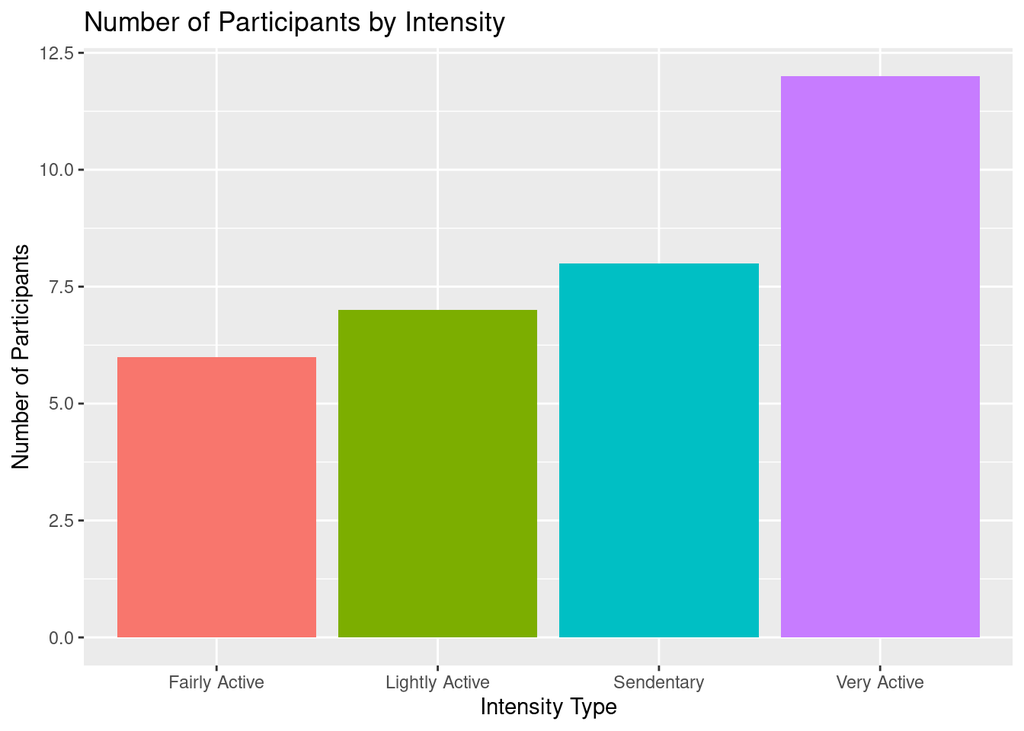

```r
participantActivity <- participantActivity %>%
  mutate(intensity =
           case_when(percent_very_active > mean(percent_very_active) ~ "Very Active",
                     percent_fairly_active > mean(percent_fairly_active) ~ "Fairly Active",
                     percent_lightly_active > mean(percent_lightly_active) ~ "Lightly Active",
                     percent_sendentary_active > mean(percent_sendentary_active) ~ "Sendentary"))

newActivity <- participantActivity %>%
  group_by(intensity) %>%
  summarise(count = n())

ggplot(newActivity, aes(x = intensity, y = count, fill = intensity)) +
    geom_histogram(stat = "identity") +
  ylab("Number of Participants") +
  xlab("Intensity Type") +
  labs(title = "Number of Participants by Intensity") +
  theme(legend.position = "none")
```

So with the unused days filtered out, this is how active the users are. A good portion of them are very active, but there are still many sedentary users. **We can focus more on sedentary users by sending them daily notifications to be more active by going on a run or walk, etc.** Lets see if there’s a good time of day to send out that notification.

#### Hourly intensities

```r
newHourlyInt <- dhourlyInt %>%
  group_by(Hour) %>%
  drop_na() %>%
  summarise(mean_total_int = mean(TotalIntensity))

head(newHourlyInt)
```

```
## # A tibble: 6 × 2
##   Hour        mean_total_int
##   <chr>                <dbl>
## 1 1:00:00 AM            1.42
## 2 1:00:00 PM           18.8
## 3 10:00:00 AM          17.6
## 4 10:00:00 PM           9.06
## 5 11:00:00 AM          16.9
## 6 11:00:00 PM           5.00
```

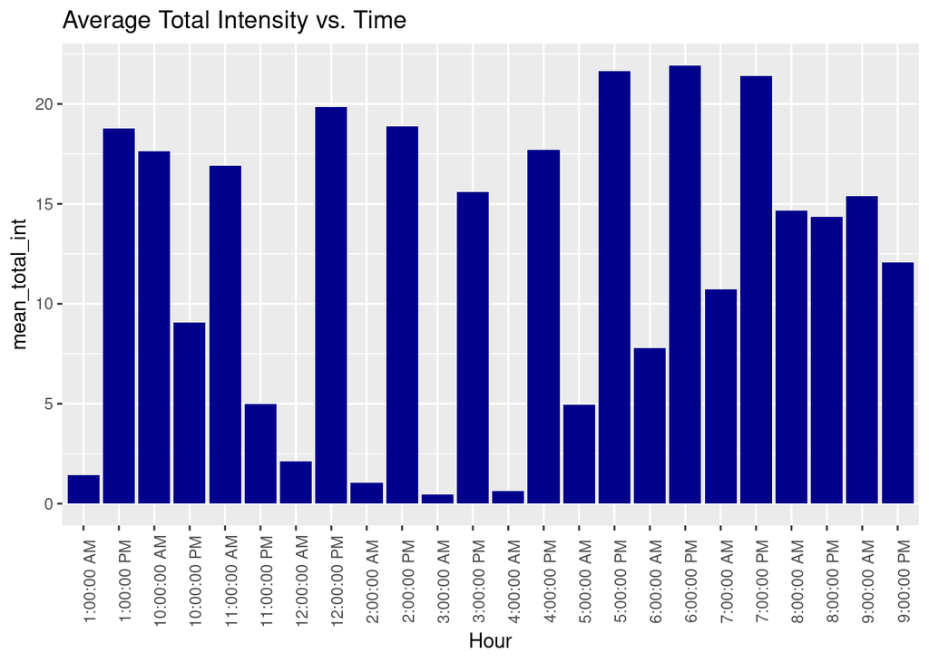

```r
ggplot(data=newHourlyInt, aes(x= Hour, y=mean_total_int))+
  geom_histogram(stat = "identity", fill = "darkblue") +
  theme(axis.text.x = element_text(angle = 90)) +
  labs(title = "Average Total Intensity vs. Time")
```

Looks like people are most active between 5pm and 7pm. **This would be a good time to send out that notification** to remind and motivate the sedentary users (or all users) to be more active.

#### Looking at sleep

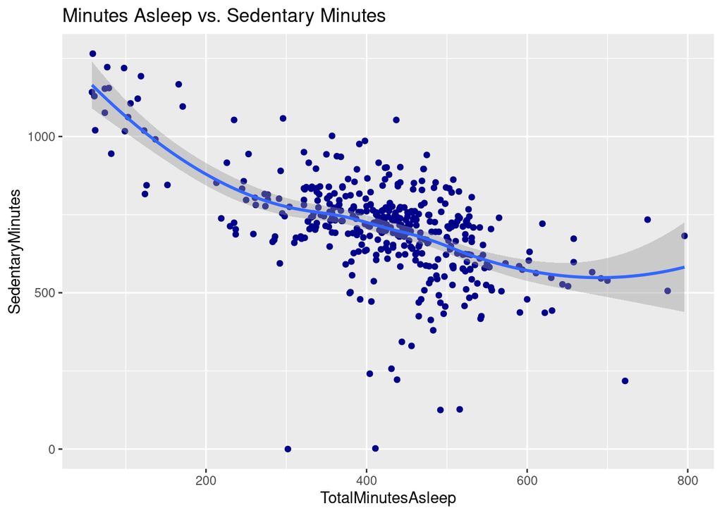

```r
merged_data <- merge(sleep, daily, by=c('Id', 'date')) %>%
  filter(SedentaryMinutes !=1440)

ggplot(data=merged_data, aes(x=TotalMinutesAsleep, y=SedentaryMinutes)) +
geom_point(color='darkblue') + geom_smooth() +
  labs(title="Minutes Asleep vs. Sedentary Minutes")
```

This is a negative correlation between sedentary minutes and total minutes asleep. This means that as sedentary minutes increase, minutes asleep decreases. If users want to improve their sleep, they can decrease their sedentary minutes. **Thus, sending that notification to run or walk between the hours of 5pm to 7pm will increase activity, reduce sedentary minutes, and increase minutes asleep.**

## Conclusion

The Bellabeat Time device is similar to the FitBit watches, and the apps are also comparable. The following marketing strategies can be used to increase usage of both devices.

1. The average steps per day are 7638, yet CDC research shows that 8000 steps or more is associated with a lower risk for mortality. The Bellabeat app can explain this health benefit. It could also send out notifications by app and/or Time device to remind users to be more active by walking or running each day.
2. Since most activity happens between 5pm and 7pm, Bellabeat should consider this a good time to send out those reminders, specifically to the more sedentary users to keep them on track.
3. A decrease in active minutes leads to a decrease in sleep, so Bellabeat can also explain the health benefits of getting at least 8 hours of sleep in the app, and how activity levels affect quality of sleep. If users want to improve their sleep, Bellabeat should send out notifications by app and/or Time device to remind users to be more active by walking or running each day.
4. Lastly, wearing the device every day is important to track each users health. Bellabeat should consider sending out notifications via app to remind users to wear their device every day for the most benefit. A good time to do this could be when the heart rate is at 0 for a specified amount of time.